# ANEMIA INFANTIL EN EL PERÚ (ENDES 2024)

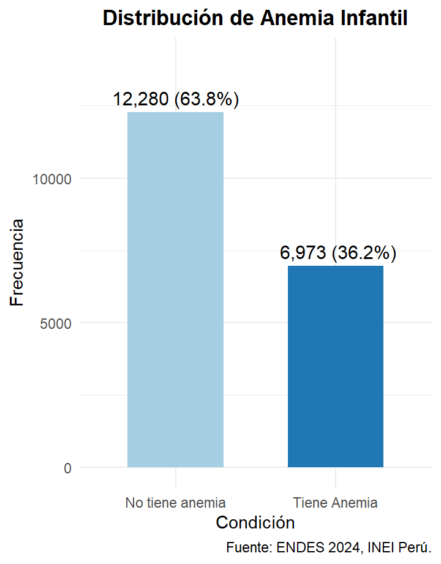

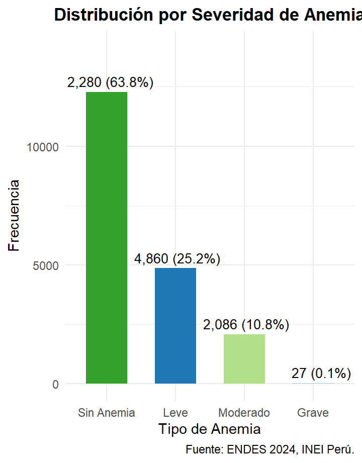

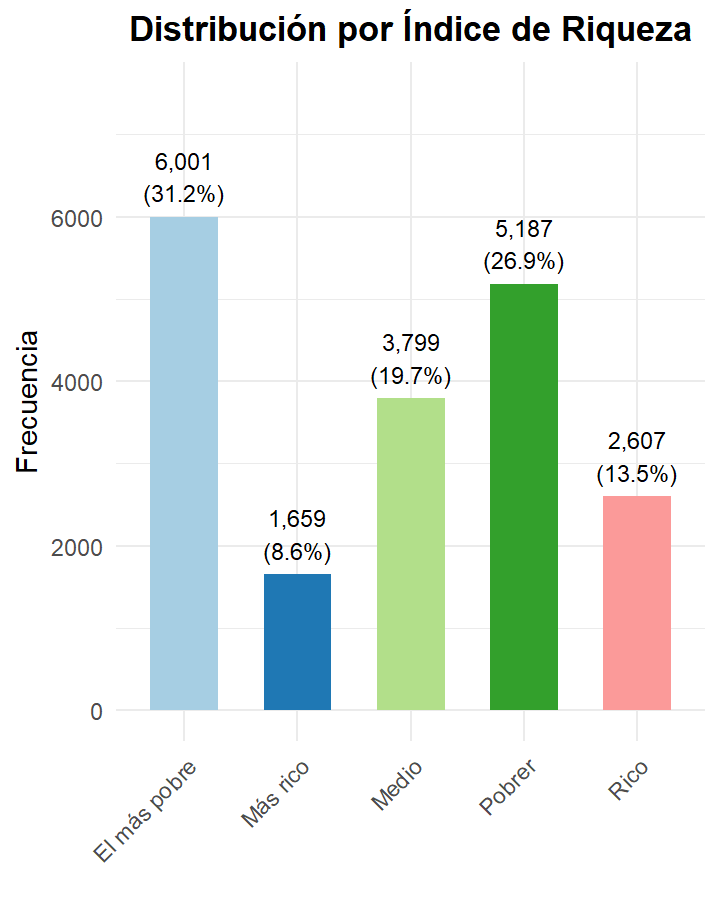

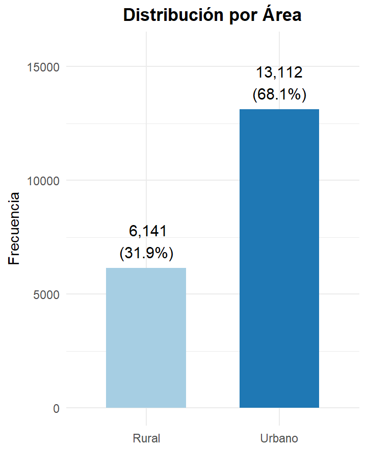

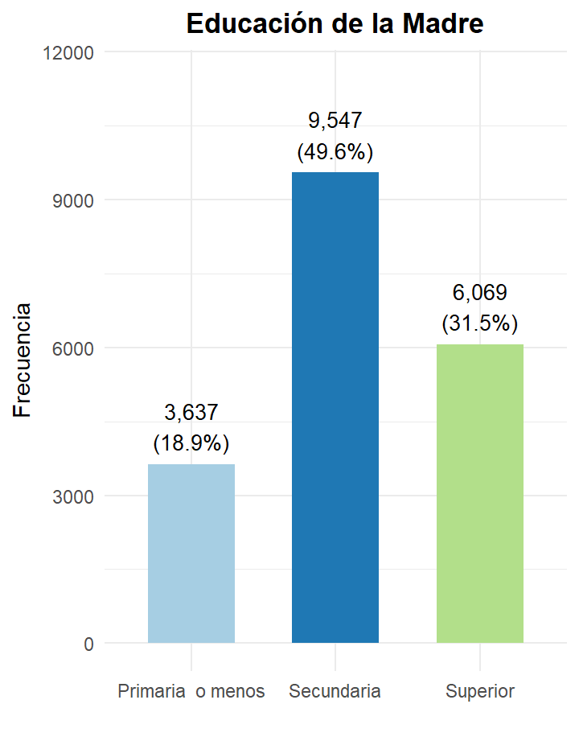

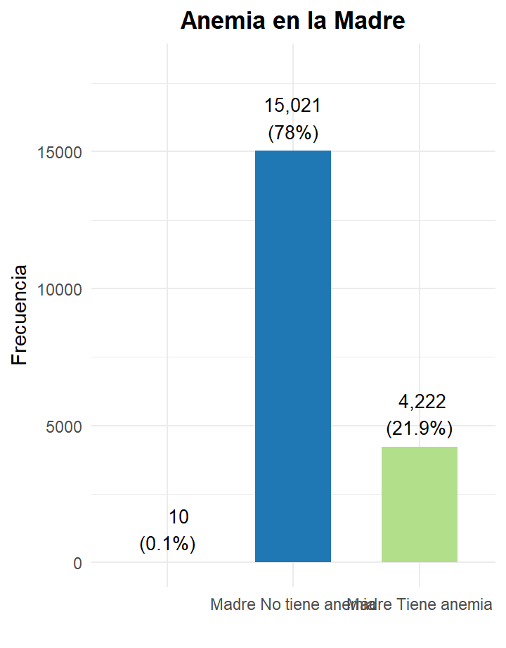

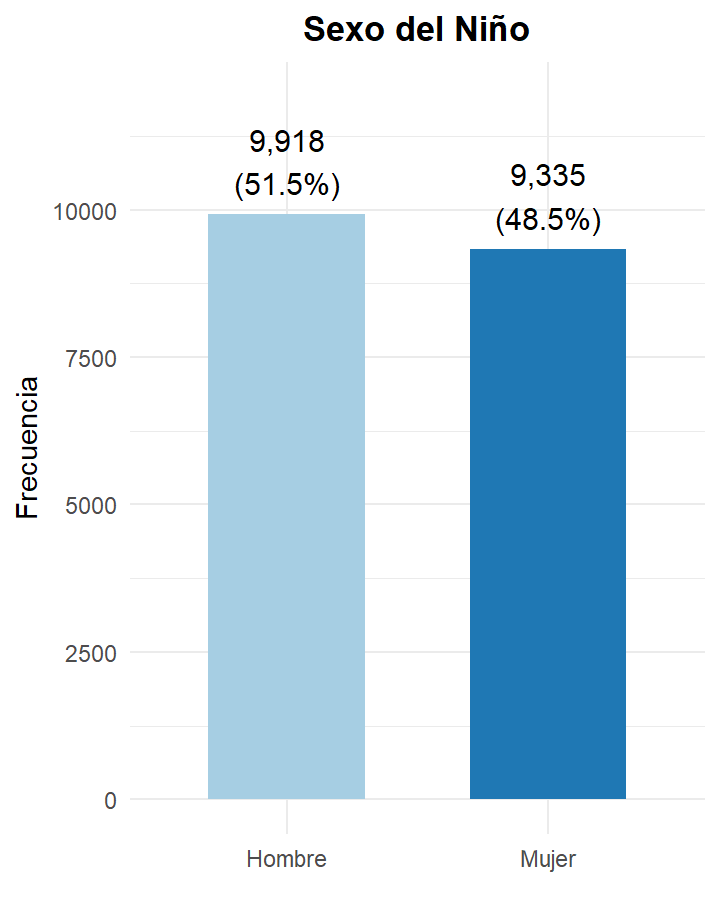

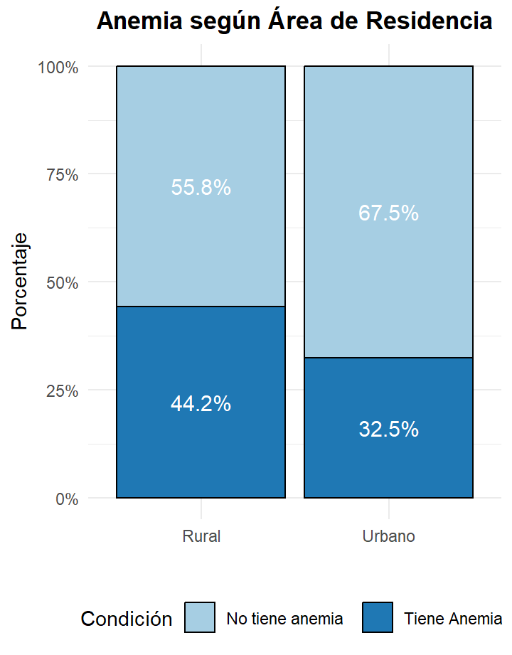

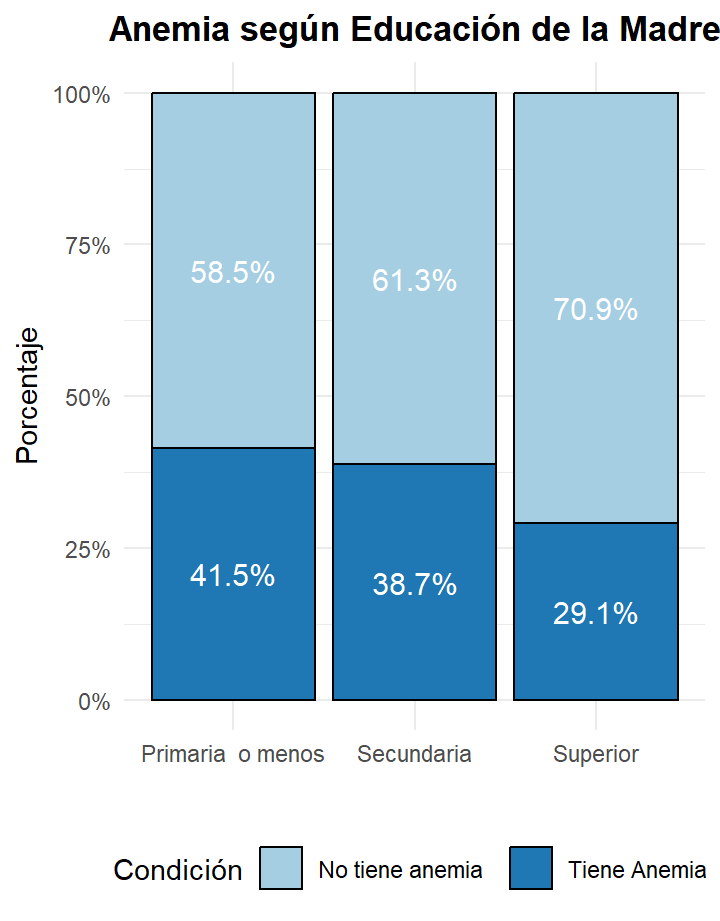

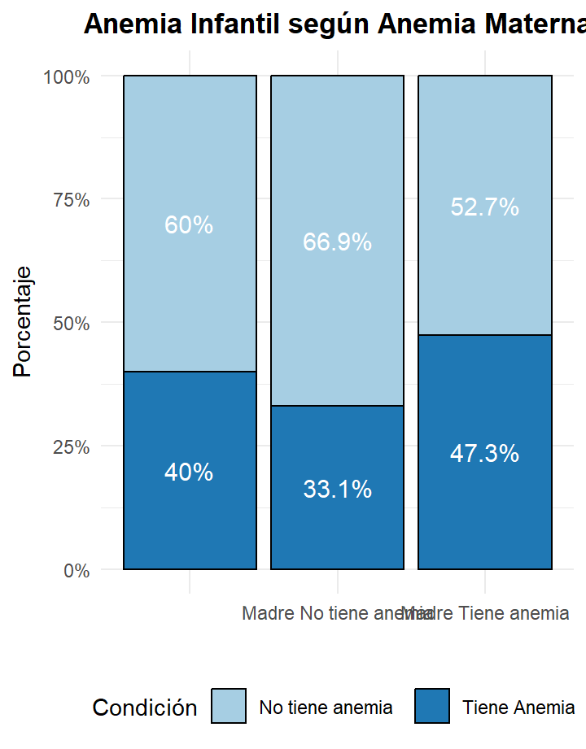

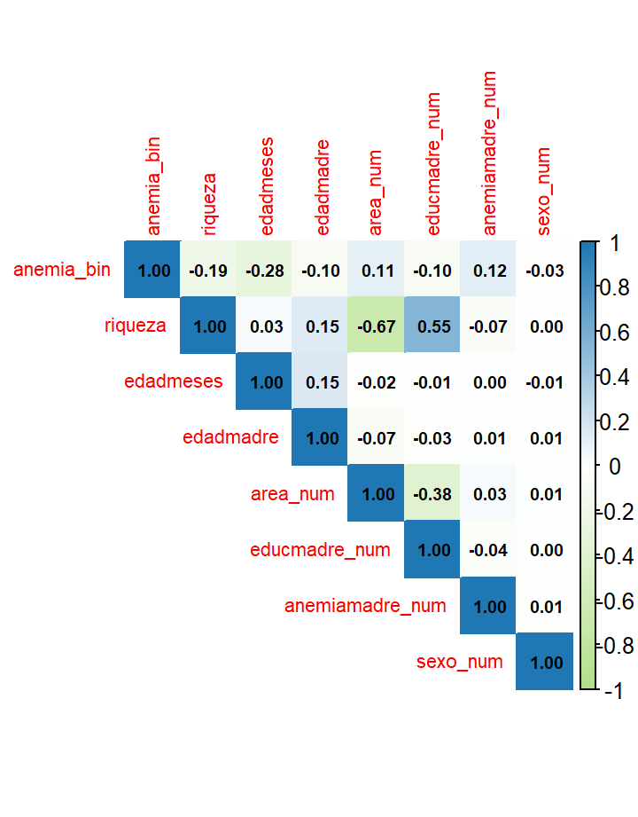

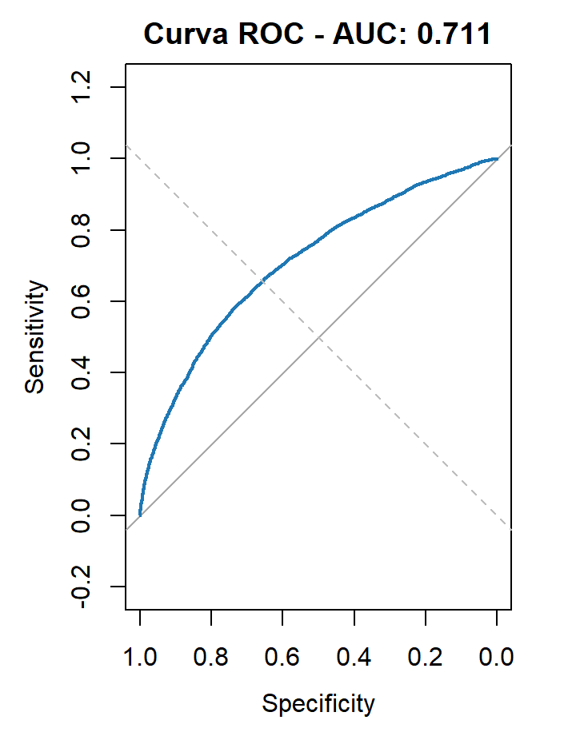

[5 more figures not shown]

# Introducción

### Regiones del Perú

25

### Niños evaluados

19,253

### Prevalencia de Anemia

36.2%

### CONTEXTO

- **La anemia infantil es un problema de salud pública crítico en el Perú:** Afecta el desarrollo cognitivo, motor y socioemocional de los niños menores de 5 años.
- **La ENDES 2024 permite analizar los determinantes de esta condición** a nivel nacional, considerando factores socioeconómicos, maternos y geográficos.
- **Objetivo del estudio:** Identificar qué factores influyen en la anemia infantil en el Perú, utilizando datos de la Encuesta Demográfica y de Salud Familiar (ENDES) 2024.

# Variable Dependiente

## Column {data-width=500}

### Definición de Anemia

La **anemia** se define según los niveles de hemoglobina ajustados por altitud:

Criterio de Clasificación de Anemia Infantil

| Nivel de Hemoglobina | Clasificación | Valor binario |
| --- | --- | --- |
| < 11.0 g/dL | Tiene Anemia | 1 |
| ≥ 11.0 g/dL | No tiene Anemia | 0 |

**Tipos de anemia por severidad:**

- **Leve:** Hemoglobina entre 10.0-10.9 g/dL
- **Moderada:** Hemoglobina entre 7.0-9.9 g/dL
- **Severa:** Hemoglobina < 7.0 g/dL

### Distribución

| Categoria | Frecuencia | Porcentaje |
| --- | --- | --- |
| No tiene anemia | 12280 | 63.8 |
| Tiene Anemia | 6973 | 36.2 |

## Column {data-width=500}

### Distribución Gráfica

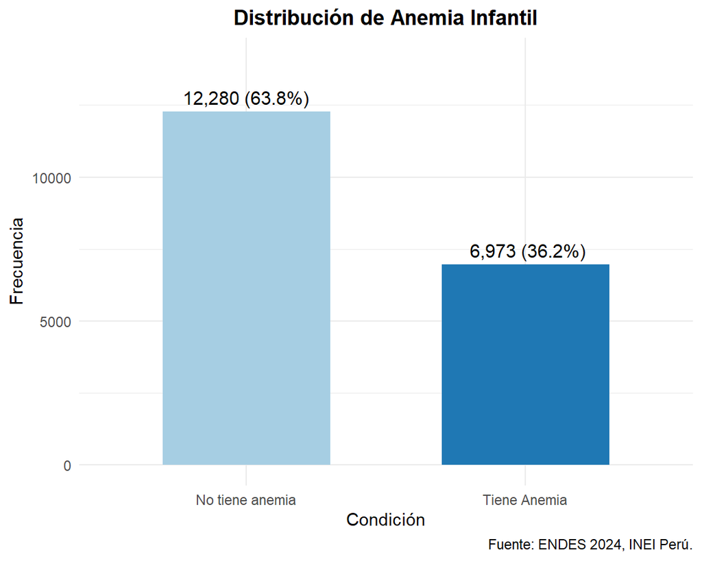

### Por Severidad

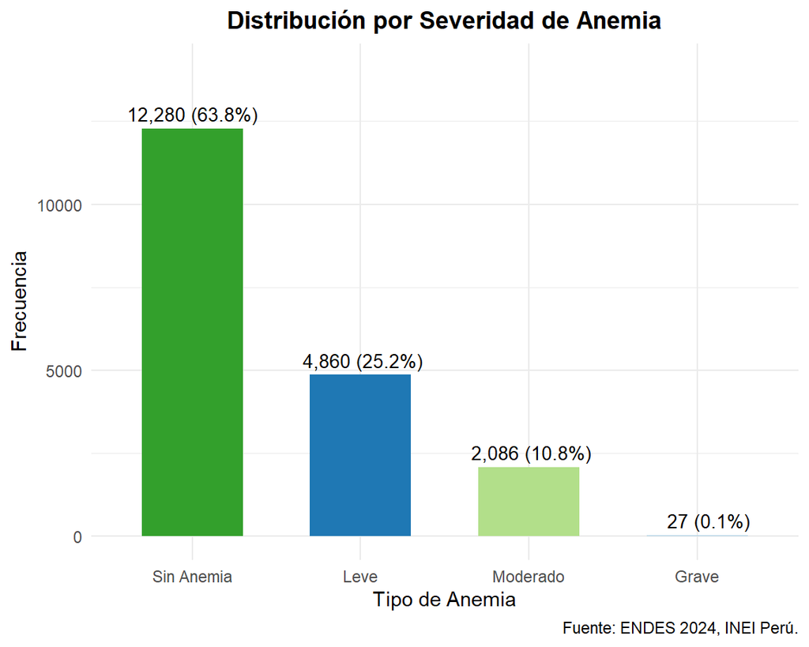

# Variables Independientes

## Column {data-width=500}

### Índice de Riqueza

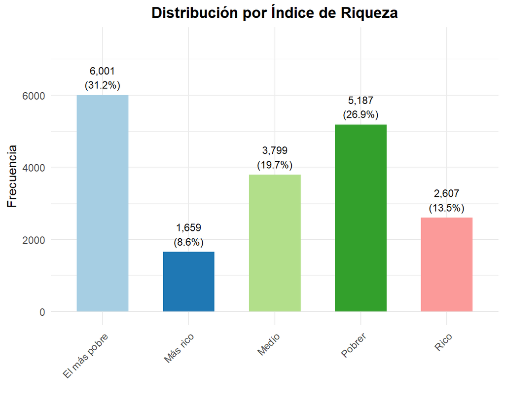

### Edad del Niño (meses)

[interactive chart not shown]

### Peso al Nacer

[interactive chart not shown]

### Edad de la Madre

[interactive chart not shown]

## Column {data-width=500}

### Área de Residencia

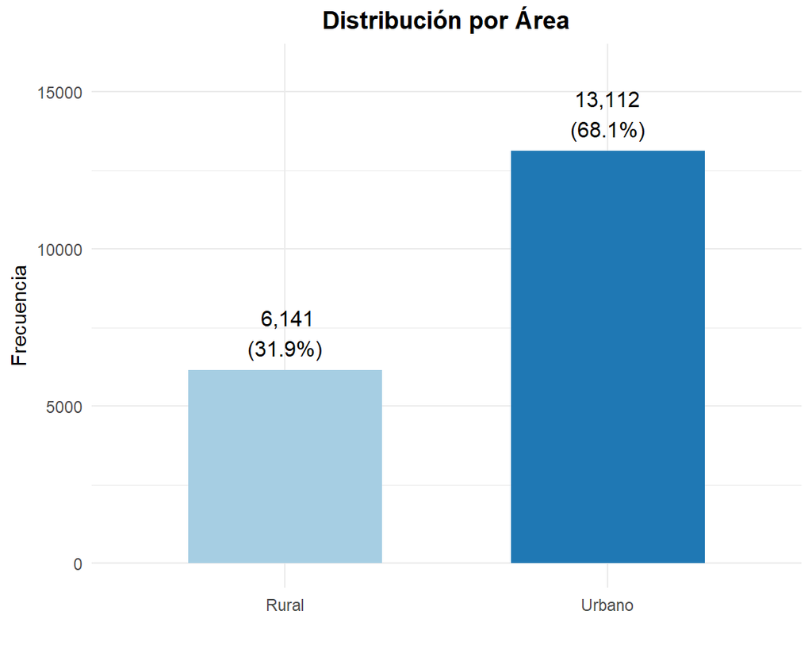

### Educación de la Madre

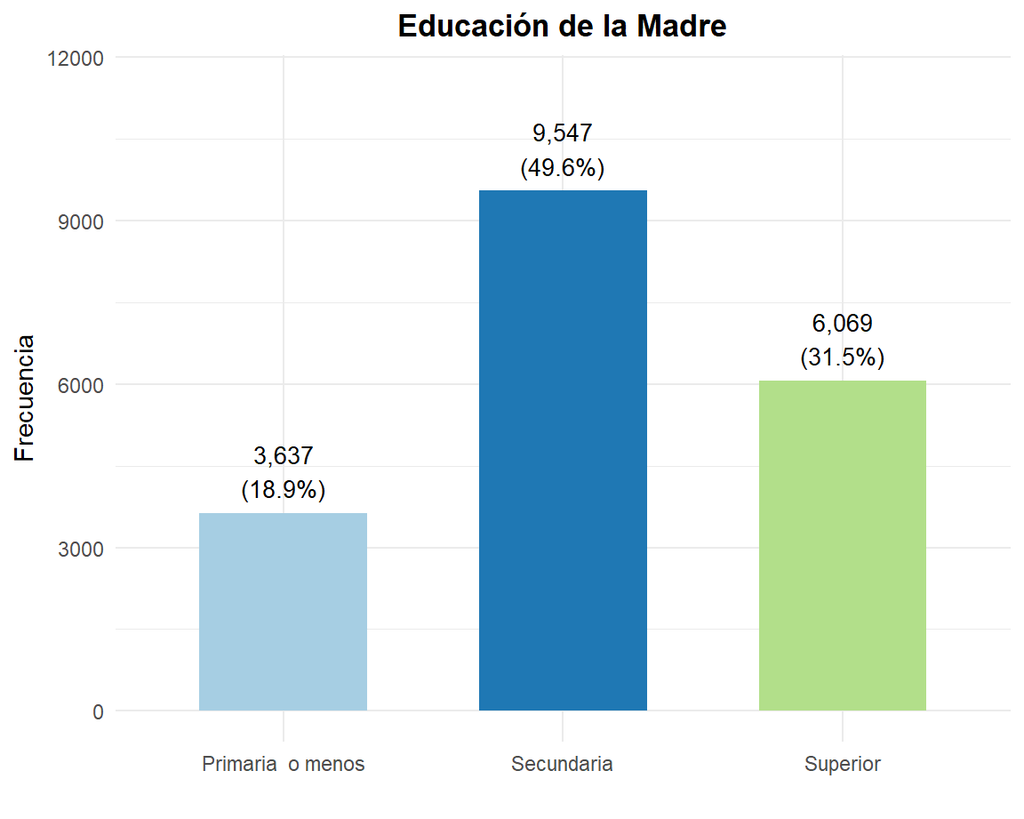

### Anemia Materna

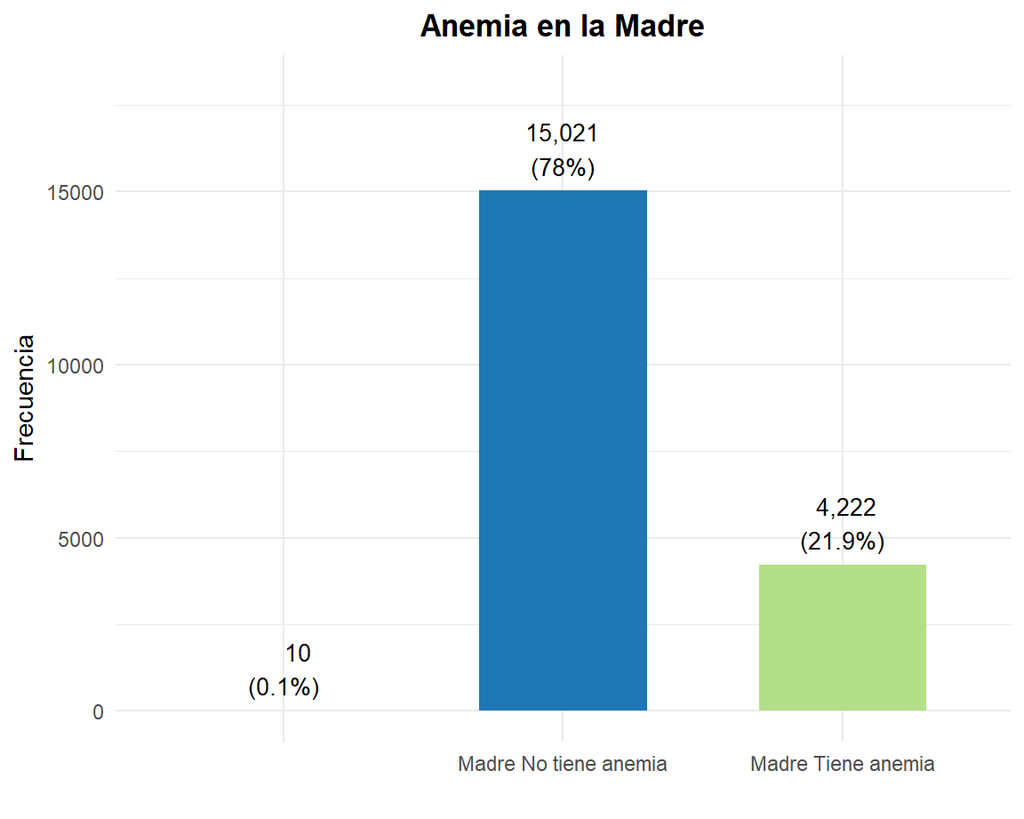

### Sexo del Niño

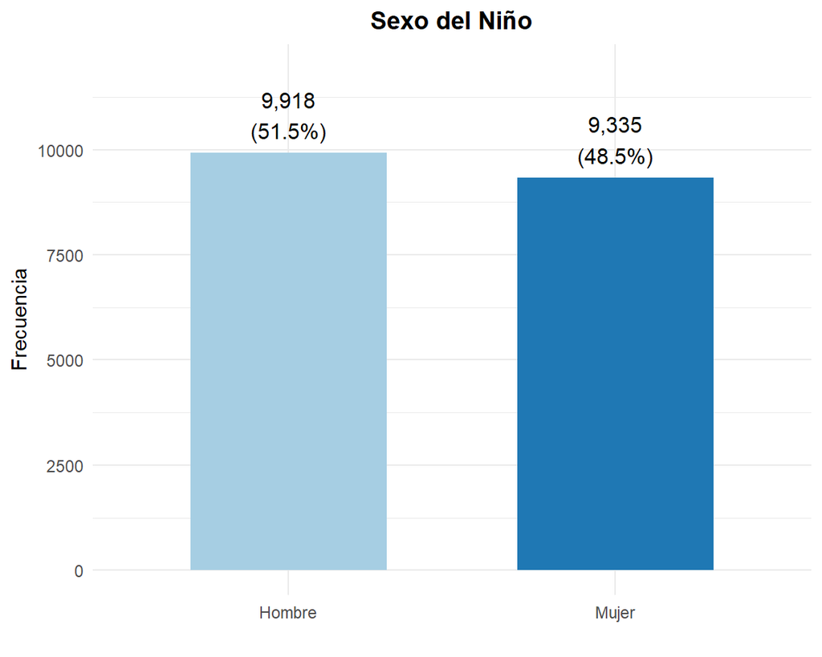

# Análisis Bivariado

### Área vs Anemia

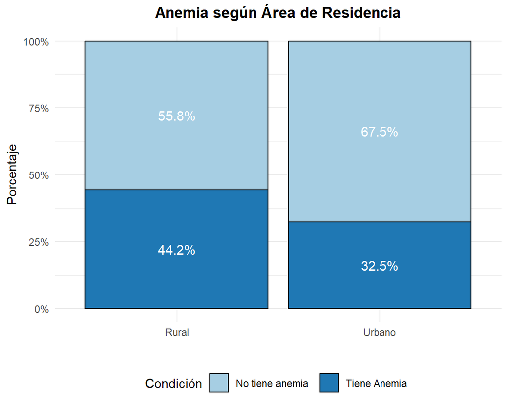

```
Chi-cuadrado = 250.93, gl = 1, p-valor < 0.001
```

**INTERPRETACIÓN:**

- La anemia es significativamente **más prevalente en zonas rurales** que en zonas urbanas.
- Esta diferencia refleja desigualdades en acceso a servicios de salud, alimentación y saneamiento.

### Educación Materna vs Anemia

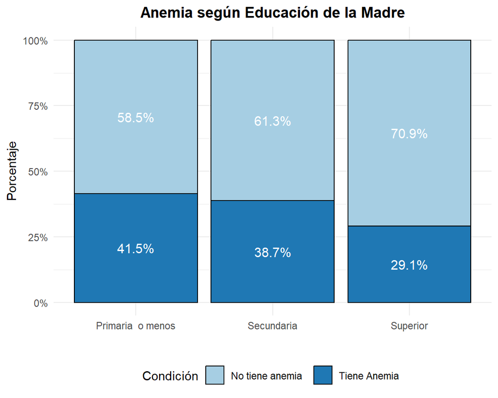

```
Chi-cuadrado = 205.01, gl = 2, p-valor < 0.001
```

**INTERPRETACIÓN:**

- A **mayor nivel educativo de la madre**, menor prevalencia de anemia en los niños.
- La educación materna es un factor protector clave.

### Anemia Materna vs Anemia Infantil

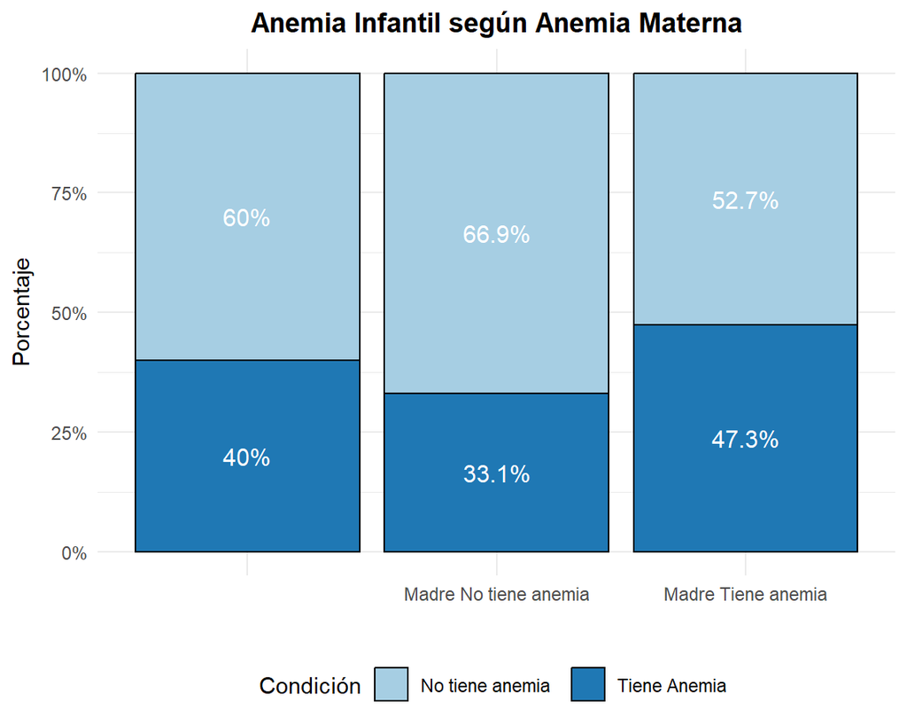

```
Chi-cuadrado = 288.95, gl = 2, p-valor < 0.001
```

**INTERPRETACIÓN:**

- Existe una **asociación significativa** entre la anemia de la madre y la anemia del niño.
- Los hijos de madres con anemia tienen mayor probabilidad de presentar anemia.

### Variables Numéricas vs Anemia

Comparación de medias (T-test)

| Variable | Media.Sin.Anemia | Media.Con.Anemia | Valor.p |
| --- | --- | --- | --- |
| Índice de Riqueza | 0.170 | -0.212 | <0.001 |
| Edad del niño (meses) | 35.895 | 26.651 | <0.001 |
| Edad de la madre | 31.161 | 29.786 | <0.001 |

**PRINCIPALES HALLAZGOS:**

# Regresión Logística

## Column {data-width=500}

### Matriz de Correlación

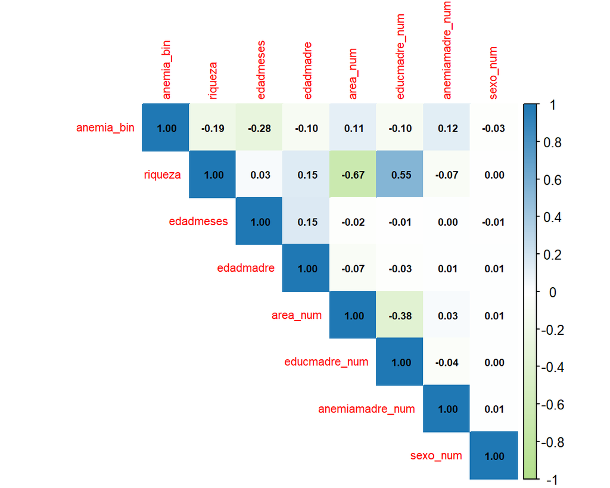

### Modelos Anidados

Regresión Logística - Odds Ratios

Modelo I

Modelo II

Modelo III

(Intercept)

0.481***

1.929***

2.662***

[0.427, 0.541]

[1.673, 2.224]

[2.166, 3.272]

riqueza

0.623***

0.622***

0.634***

[0.594, 0.653]

[0.592, 0.654]

[0.603, 0.667]

anemiamadre_num

1.728***

1.826***

1.832***

[1.610, 1.855]

[1.696, 1.967]

[1.701, 1.974]

educmadre_num

1.035

1.001

0.984

[0.984, 1.090]

[0.948, 1.056]

[0.933, 1.039]

area_num

0.879**

0.875**

0.881**

[0.807, 0.958]

[0.800, 0.957]

[0.806, 0.964]

sexo_num

0.860***

0.861***

[0.807, 0.916]

[0.808, 0.917]

edadmeses

0.961***

0.961***

[0.959, 0.963]

[0.959, 0.963]

edadmadre

0.990***

[0.985, 0.995]

Num.Obs.

19253

19253

19253

AIC

24261.7

22678.3

22662.3

BIC

24301.0

22733.4

22725.2

Log.Lik.

-12125.845

-11332.150

-11323.161

F

225.133

359.025

309.346

RMSE

0.47

0.45

0.45

- p < 0.1, * p < 0.05, ** p < 0.01, *** p < 0.001

### Comparación de Modelos

Comparación de Modelos

| Resid. Df | Resid. Dev | Df | Deviance | Pr(>Chi) |
| --- | --- | --- | --- | --- |
| 19248 | 24251.69 | NA | NA | NA |
| 19246 | 22664.30 | 2 | 1587.3887 | 0 |
| 19245 | 22646.32 | 1 | 17.9794 | 0 |

### Interpretación de Resultados

**🔍 INTERPRETACIÓN DE ODDS RATIOS (Modelo III):**

### Evaluación del Modelo

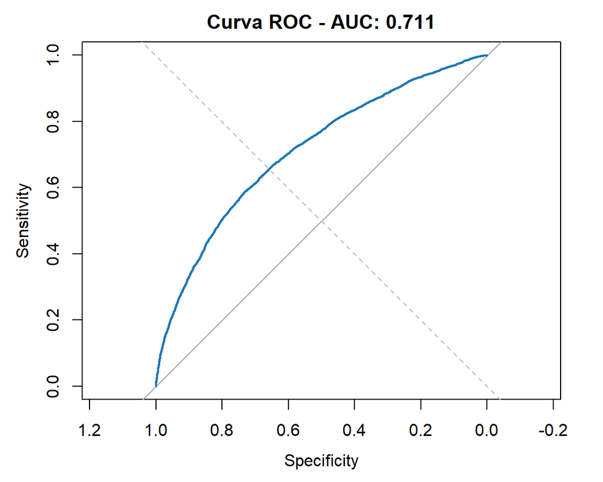

**El AUC indica la capacidad predictiva del modelo.**

# EFA

## Column {data-width=400}

### Correlación

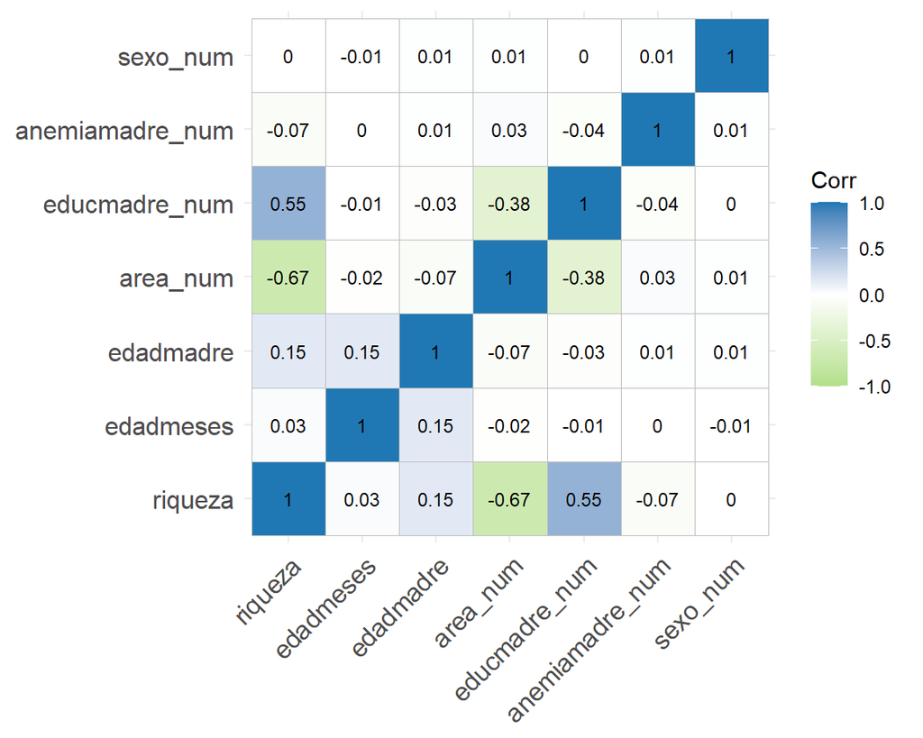

### Verificación KMO

```
KMO Overall: 0.603
```

```
KMO por variable:
```

```
        riqueza       edadmeses       edadmadre        area_num   educmadre_num
          0.570           0.533           0.419           0.625           0.678
anemiamadre_num        sexo_num
          0.656           0.468
```

**Interpretación:** Un KMO > 0.5 indica que el análisis factorial es apropiado.

### Bartlett Test

```
Chi-cuadrado: 19817.61
```

```
p-valor: 0e+00
```

### Análisis Factorial

```
Loadings:
                MR1    MR2
riqueza          0.984
edadmeses
edadmadre               0.788
area_num        -0.672
educmadre_num    0.564
anemiamadre_num
sexo_num

                 MR1   MR2
SS loadings    1.743 0.693
Proportion Var 0.249 0.099
Cumulative Var 0.249 0.348
```

### Diagrama Factorial

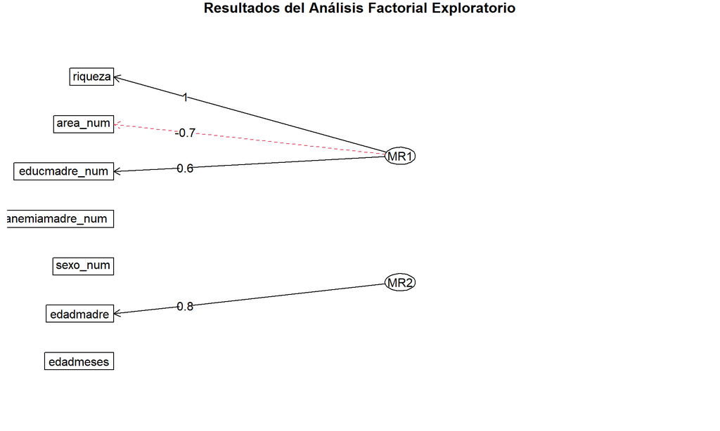

### Interpretación del EFA

**🔍 ANÁLISIS FACTORIAL EXPLORATORIO**

El análisis factorial permite identificar dimensiones latentes:

**Métricas de ajuste:**

```
TLI: 0.999
```

```
RMSEA: 0.005
```

# Clustering

## Column {data-width=400}

### Número Óptimo de Clusters

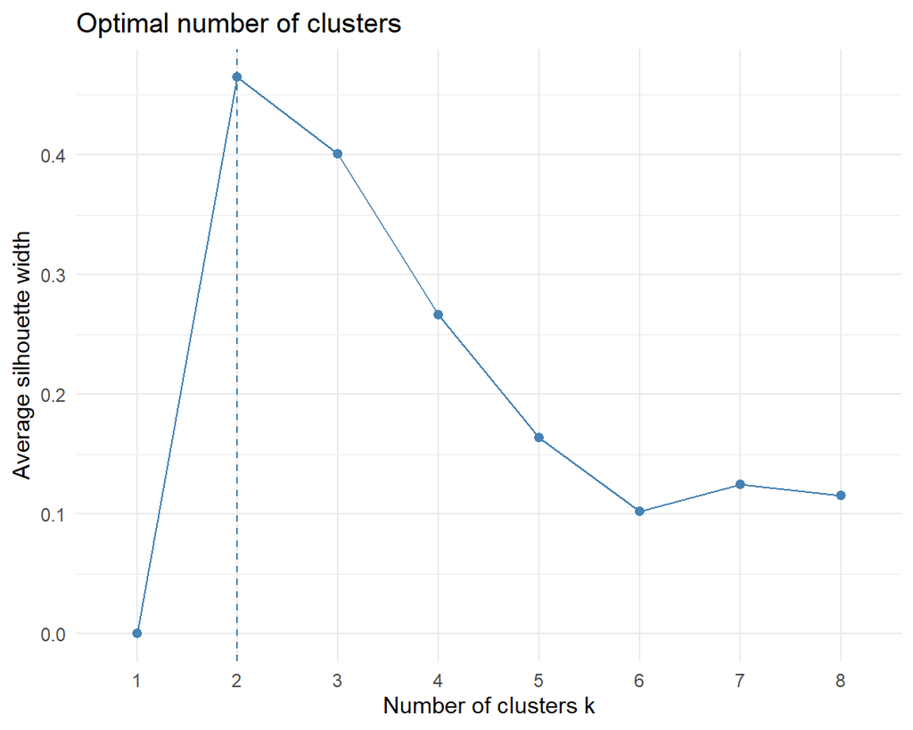

### Silueta de Clusters

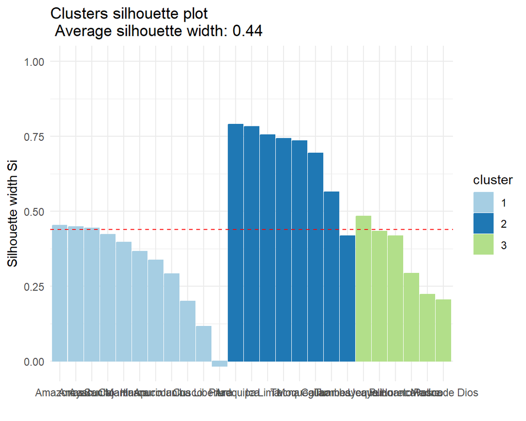